# Homework2

Leila Ramirez

2025-09-17

```r
library(ggplot2)
library(kableExtra)

TallBuild <- read.csv ("Homework2_TallestBuildings.csv")
```

# Introduction

The dataset includes information on the 200 tallest buildings, both completed and under construction, including variables like the location, height, material, and more. The goal is to explore relationships and possible correlations between variables, like height and status.

# RQ1: How Tall Are the World’s Tallest Buildings?

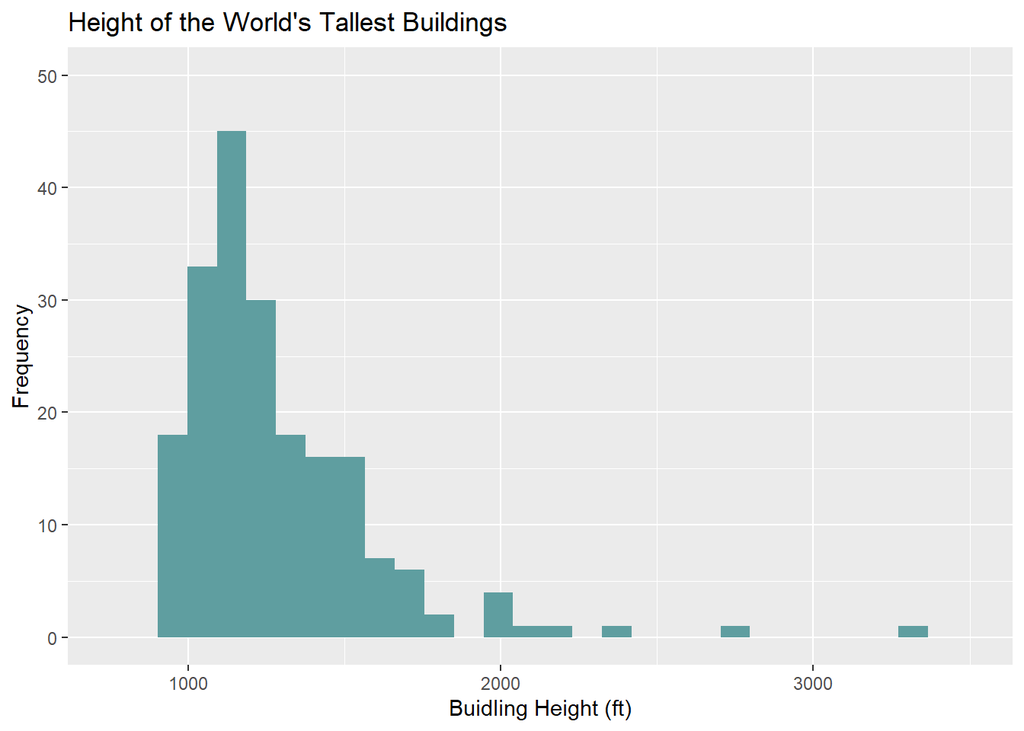

```r
TallBuild$HeightFt<- TallBuild$Height * 3.28084

TB_ggplot <- ggplot(TallBuild)
TB_ggplot + geom_histogram( aes(x=HeightFt), fill = "cadetblue", bins = 30, na.rm = TRUE) + labs (title = "Height of the World's Tallest Buildings", x = "Buidling Height (ft)", y= "Frequency") + xlim(750, 3500) + ylim (0, 50)
```

The data is right skewed with a median of 1202.43 and an IQR of 309.22. A large portion of the world’s tallest buildings are between 750 and 1,500 feet.

# RQ2: For Completed Buildings, is There a Relationship Between the Year it was Completed and Height?

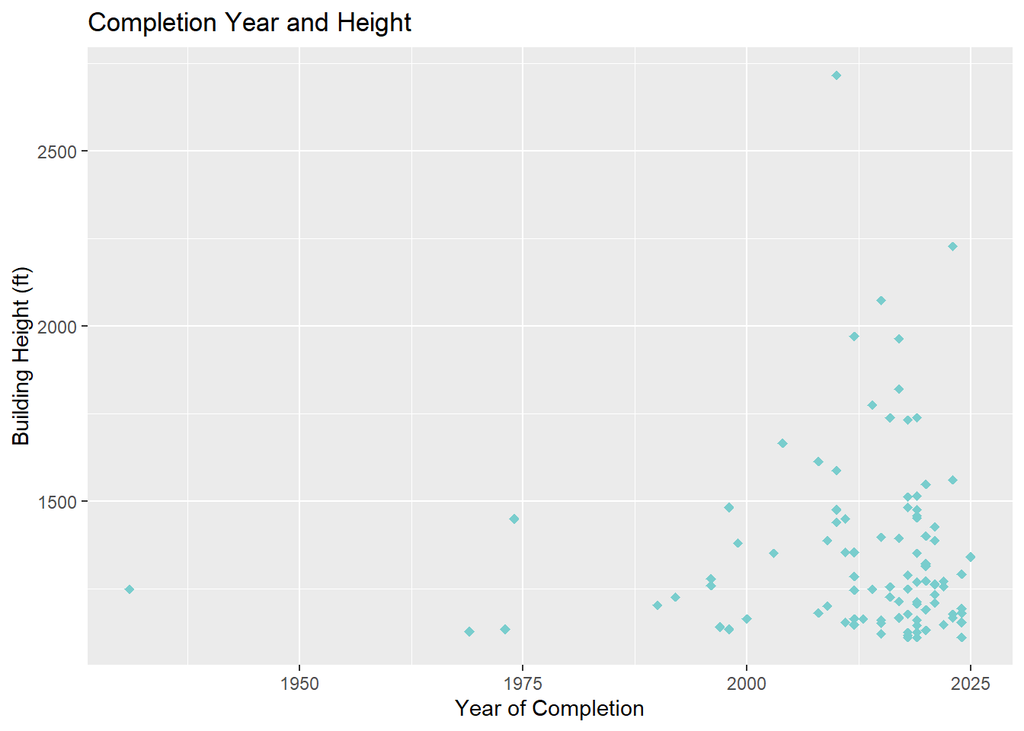

```r
CompBuild <- TallBuild[TallBuild$Status == "Completed",]

CompTB_ggplot <- ggplot(CompBuild)
CompTB_ggplot + geom_point (aes (x = CompletionYear, y= HeightFt), color = "darkslategray3", size = 2, shape = 18) + labs (title = "Completion Year and Height", x = "Year of Completion", y = "Building Height (ft)")
```

There is no strong relationship between the year the building was completed and the building height as indicated by its little to no correlation: 0.0391. However, there is a large number of tall buildings that were completed within the past 10 years.